# Report 4

Jason Ola

2021-03-03

## Import libraries

```r
library(tidyverse)
```

## Part 1

Let’s recreate the data for the pie chart, we also factor our sector variable in order of apparition

```r
pie_tax <- tribble(
  ~sector, ~money,
  "Economie publique",   4.08,
  "Finances et impôts",   5.47,
  "Prévoyance sociale", 28.50,
  "Sécurité publique", 7.60,
  "Trafic", 4.09,
  "Santé", 14.78,
  "Enseignement", 28.92,
  "Environnement", 1.19,
  "Culture et loisirs", 1.60,
  "Administration générale",   3.77,
)%>%
  mutate(sector = fct_inorder(sector),
         year = lubridate::as_date("2019-01-01"))
```

Now plot a pie chart

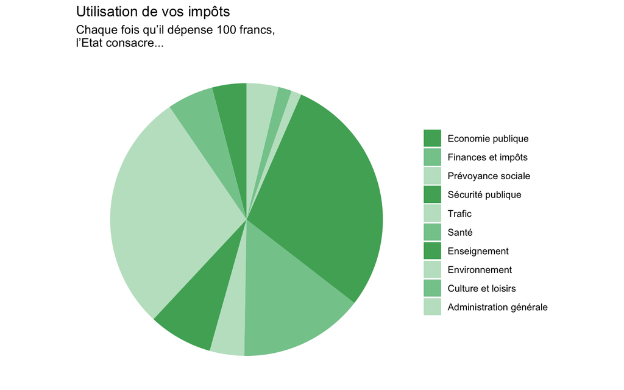

```r
pie_tax %>%
  ggplot(aes(x = "",
             y = money,
             fill = sector))+
  geom_col(width = 1)+
  coord_polar("y", start = 0)+
  scale_fill_manual(values = c("#4EAD65","#84C99B","#C0E2CA","#4EAD65","#C0E2CA","#84C99B",
                               "#4EAD65","#C0E2CA","#84C99B","#C0E2CA"))+
  labs(title = "Utilisation de vos impôts",
       subtitle = "Chaque fois qu’il dépense 100 francs,
l’Etat consacre...")+
  theme_void()+
    theme(legend.title = element_blank())
```

## Part 2

Let’s now improve our chart and highlight the fact that “Education, social, and health accounts for 72.20% of the spending”

```r
pie_tax <- pie_tax %>%
  mutate(highlight = case_when(sector == "Prévoyance sociale" ~ "#349439",
                               sector == "Santé" ~ "#2bad32",
                               sector == "Enseignement" ~ "#19bf22",
                               TRUE ~ "gray")) %>%
  mutate(highlight = fct_inorder(highlight))
```

I create an other table to have group others from main sectors

```r
pie_tax_with_others <- pie_tax %>%
    mutate(sector = if_else(highlight == "gray", "Autres", as.character(sector)))
```

I create a variable for percentage of main sectors to use later in caption

```r
percentage <- pie_tax_with_others %>%
  filter(sector !="Autres") %>%
  summarise(sum(money)) %>%
  pull()
```

I plot the chart

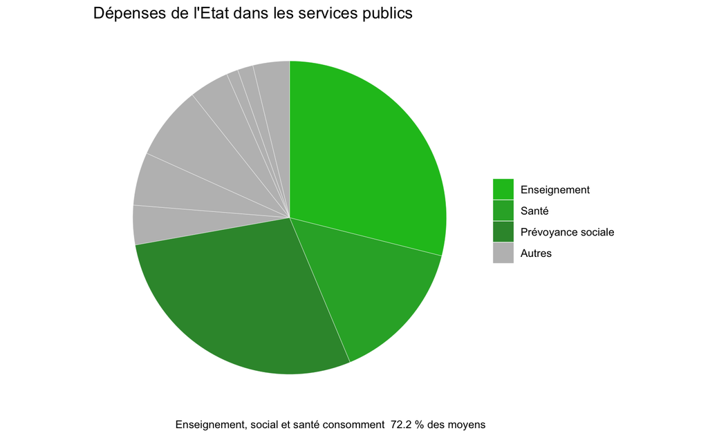

```r
pie_tax_with_others %>%
  ggplot(aes(x = "",
             y = money,
             fill = highlight))+
  geom_col(width = 1,
           color = "white",
           size = 0.1)+
  coord_polar("y", start = 0)+
  scale_fill_identity(guide = guide_legend(reverse = TRUE),
                      breaks = pie_tax_with_others$highlight,
                      labels = pie_tax_with_others$sector)+
  labs(title = "Dépenses de l'Etat dans les services publics",
       caption = paste("Enseignement, social et santé consomment ",
                       as.character(percentage),
                       "% des moyens\n"))+
  theme_void()+
  theme(legend.title = element_blank())
```

## Part 3

### Alternatives :

I thought about just using the data for a regular bar chart where we can have a clear idea of different sizes because people have problems evaluating angles of pie charts.

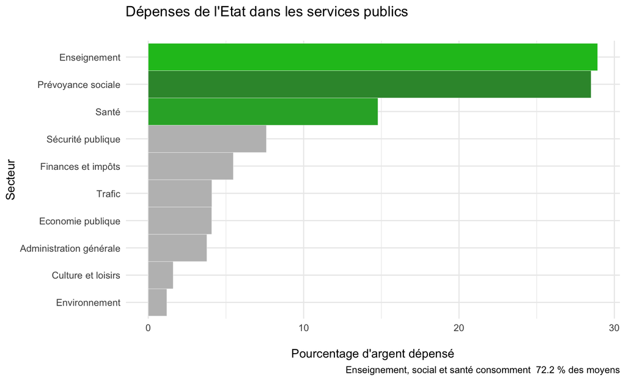

```r
pie_tax %>%
  arrange(money) %>%
  ggplot(aes(x = money,
             y = fct_inorder(sector),
             fill = highlight))+
  geom_col(width = 1,
           color = "white",
           size = 0.1)+
  scale_fill_identity(breaks = pie_tax_with_others$highlight,
                      labels = pie_tax_with_others$sector)+
  labs(title = "Dépenses de l'Etat dans les services publics\n",
       x = "\nPourcentage d'argent dépensé",
       y = "Secteur",
       caption = paste("Enseignement, social et santé consomment ",
                       as.character(percentage),
                       "% des moyens\n"))+
  theme_minimal()+
  theme(legend.title = element_blank())
```

I also thought about doing a better pie chart : the donut chart. I has the same feel as pie chart but it removes the angle problem and we have a better distance perception.

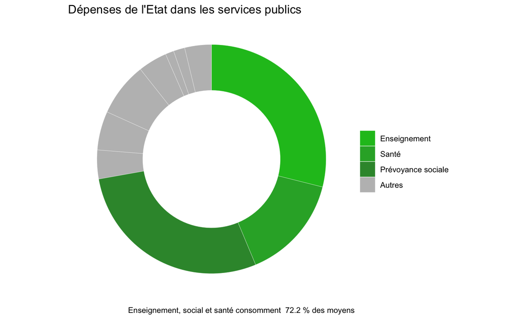

```r
pie_tax_with_others %>%
  ggplot(aes(x = 2,
             y = money,
             fill = highlight))+
  geom_col(width = 1,
           color = "white",
           size = 0.1)+
  coord_polar("y", start = 0)+
  xlim(0,2.5)+
  scale_fill_identity(guide = guide_legend(reverse = TRUE),
                      breaks = pie_tax_with_others$highlight,
                      labels = pie_tax_with_others$sector)+
  labs(title = "Dépenses de l'Etat dans les services publics",
       caption = paste("Enseignement, social et santé consomment ",
                       as.character(percentage),
                       "% des moyens\n"))+
  theme_void()+
  theme(legend.title = element_blank())
```

## Part 4

```r
pie_tax_2018 <- tribble(
  ~sector, ~money,
  "Economie publique",   4.8,
  "Finances et impôts",   8.43,
  "Prévoyance sociale", 27.87,
  "Sécurité publique", 7.12,
  "Trafic", 3.58,
  "Santé", 12.85,
  "Enseignement", 28.50,
  "Environnement", 1.16,
  "Culture et loisirs", 1.65,
  "Administration générale",   4.04,
)%>%
  mutate(sector = fct_inorder(sector),
         year = lubridate::as_date("2018-01-01"))
```

```r
pie_tax_2017 <- tribble(
  ~sector, ~money,
  "Economie publique",   4.26,
  "Finances et impôts",   4.8,
  "Prévoyance sociale", 27.55,
  "Sécurité publique", 7.49,
  "Trafic", 4.47,
  "Santé", 15.26,
  "Enseignement", 28.97,
  "Environnement", 0.95,
  "Culture et loisirs", 1.98,
  "Administration générale",   4.27,
)%>%
  mutate(sector = fct_inorder(sector),
         year = lubridate::as_date("2017-01-01"))
```

```r
full_data <- bind_rows(pie_tax,pie_tax_2018,pie_tax_2017)
```

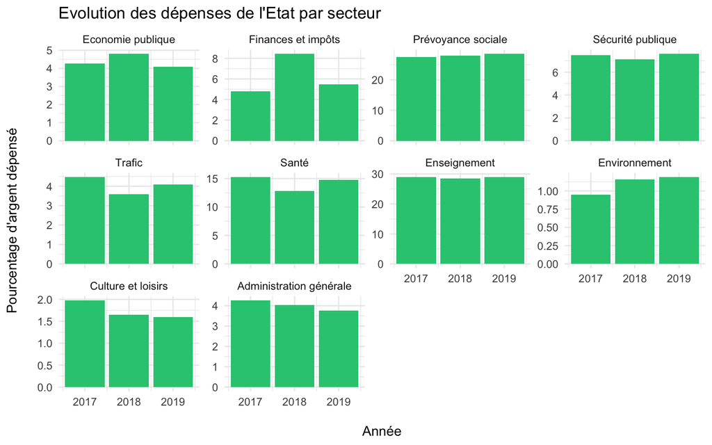

```r
full_data %>%
  ggplot()+
  geom_col(aes(year,money), fill = "#2ac981")+
  facet_wrap(vars(sector), scales = "free_y")+
  labs(title = "Evolution des dépenses de l'Etat par secteur",
       x = "\nAnnée",
       y = "Pourcentage d'argent dépensé\n")+
  theme(axis.text.x = element_text(angle = 90)) +
  theme_minimal()
```